# ToDo

## Dane PISA

Smieszny pdf w ktorym jest co nieco informacji o pytaniach:  
https://www.oecd-ilibrary.org/docserver/9789264273856-19-en.pdf?expires=1570538884&id=id&accname=guest&checksum=D82A0626AA2869CBC7A2F21A10C55776

Zrobione:  
1. A~ Skrypt `procent_panstw` dzielacy dane na panstwa i podajacy procentowy udzial kazdego z wyroznionych elementow w przystepnej formie. Mozliwa pozniejsza modyfikacja do specyficznych celow.  
2. A~ Tabelki typu `powtarzanie_klasy` informujace o tym w jakich panstwach i jak bardzo uczniowie powtarzali klasy. Najwazniejsza: `powtarzanie_klasy_merged`.  
3. A~ Wykres `posiadanie biurka`. Oczywiście do przyszlej poprawy.  
4. P~ Wszelkie zebrane dane są w pliku:  
- Europa.R - porównanie Wielkiej Brytanii do innych państw, wyniki względem Europy i państw o najlepszym systemie szkolnictwa  
- GBR_schools.R - wszystkie porównania uczniów w szkołach w Wielkiej Brytanii (nie opisuję jakie gdyż wyniki są już ogarniete i przedstawione w pliku Raport.Rmd)  
Ciekawe o uczniach:  
1. Posiadanie własnego pokoju do nauki/biórka: `CY6_QST_MS_STQ_PBA_Final`: `ST011Q01TA`  
2. Jak duzo maja samochodow, instrumentow muzycznych?: `ST012Q02TA`  
3. Jak duzo ksiazek?: `ST013Q01TA`  
4. Powtarzanie klasy w kontekscie panstwa: `ST127Q01TA`  
5. Poczucie przynaleznosci spolecznej: `ST034Q01TA`  
6. Uwaga na zajeciach: `ST097Q01TA`, `ST098Q01TA`  
7. Ciekawostka: Jak nazywa sie kurs: `ST065Q01NA`  
8. Uwaga nauczycieli do uczniow: `ST100Q01TA`  
9. Dyskucje o nauce na zajeciach: `ST103Q01NA`  
10. Informacje o postepach: `ST104Q01NA`  
11. Opinia o zanieczyszczeniu srodowiska: `ST092Q01TA`  
12. Zaciekawienie ucznia przedmiotem: `ST094Q01NA`  
13. Cel uczenia sie: `ST113Q01TA`  
14. Jest tam gdzieś pytanie, ile czasu spędzasz na nauce poza szkola.  
15.  
Ciekawe o rodzicach: `cy6_ms_cmb_stu_qqq.sas7bdat`  
1. Dziecko oglada science on TV: `PA002Q01TA`  
2. Czyta science fiction: `PA002Q03TA`  
3. Chodzi na koła naukowe: `PA002Q05TA`  
4. Naprawia zepsute rzeczy: `PA002Q08NA`  
5. Rodzice rozmawiaja z dzieckiem o szkole: `PA003Q01TA`  
6. 7. 8. 9. 10.

Cele:  
1. Raport z pierwszej części projektu przedstawia wyniki pobieżnej analizy szkół w Wielkiej Brytanii i uczniów:  
- sprawdzono miedzy soba uczniow ze szkol i ich wyniki  
- rodzicow - skad sa i do jakich szkol wysylaja dzieci  
- wyniki uczniow w podziale na regiony, szkoly i szkoly okreslone poprzez uzyskiwany fundusz  
2. Druga część projektu ma być głębszą analizą - SZUKAMY HISTORII w uzyskanych w pkt. 1. wyników.  
Zadania:  
NOTKA - zrobic wykres o wynikach z podzialem tylko na szkoly prywatne i publiczne  
1. Porównać wyniki uczniow z państwami o podobnym rozwoju - dzielimy na prywatne i publiczne a uczniów na płcie.  
2. Zrobić schemat psychologiczny danych uczniów i porównywać te dane między sobą:  
- wybrać ciekawe zagadnienia do schematu psychologicznego  
- wplyw stresu? tylko co moze na stres wplywac?  
INTERNET : Profil psychologiczny tworzą:  
1. osobowość,  
2. postawy wobec siebie i innych ludzi, dóbr, problemów, spraw spornych i kontrowersyjnych,  
3. sposoby myślenia,  
4. motywy działania,  
5. wyznawane wartości,  
6. poczucie przynależności do rodziny, grupy społecznej, zawodowej i kraju,  
7. stosunek do ryzyka oraz innowacji,  
8. znaczenie przywiązywane do rodzajów, poziomu i sposobów zaspokajania potrzeb.  
Co można wziac:  
- zainteresowanie rodzicow dzieckiem  
- pochodzenie rodzicow - Czy urodziles sie w GB? `ST019AQ01T`, Czy twoja mama? `ST019BQ01T`, Czy Twoj tata? `ST019AQ01T`  
- zamoznosc - `ESCS` $0$ to średnia, i im bardziej na $+$, tym bogatsi  
- latwosc zawierania znajomosci/jak widzi siebie w szkole/itp  
- miesiac urodzin `ST003D02T`

## Co mozna robic:

Mozna wywolywac funkcje `srednia_sponsorowanych_GBR` na elementach wektora `col_ext`, oraz `srednia_prywatnych_porownanie` na elementach wektora `col`.

## Wykresy (MichBur):

1. Presja ruwiesnicza.
2. Szkoly w wielkiej brytanii(podzial na fundusze).
3. w szkolach prywatnych jest duzo nie-brytyjskich dzieci:
1. Wyniki testów w zależnosci od narodowości rodziców(lubie ten wykres, ale nie wiem, czy sie nada)
2. -Jaki procent uczniów w specyficznych szkołach ma jakich rodziców  
   -Szkoły, do jakich rodzice wysyłają swoje dzieci
4. Uczenie jezyka(ojczystego i innego). W GBR w szkolach prywatnych rezygnuje sie z jezykow obcych na rzecz jezyka ojczystego. W Polsce odwrotnie(punkt 4 w `presja ruwiesnicza` w tym dokumencie)
5. Zadowolenie z nauki(brak korelacji miedzy publiczna i prywatna) #TODO.

## Presja ruwiesnicza:

1. `srednia_prywatnych_porownanie(col[9]) # jestem ambitny` anglicy sa bardziej ambitni i `srednia_prywatnych_porownanie(col[10]) # chce byc najlepszy` tu tez
2. `srednia_prywatnych_porownanie(col[24]) # Czuje sie samotny` anglicy bardziej niz polacy i `srednia_sponsorowanych_GBR(col_ext[23])` w szkolach niezaleznych sa bardziej samotni niz w publicznych.
3. !! `srednia_prywatnych_porownanie(col[28]) # W roku szkolnym spedzilem okolo () godzin na nauce` anglicy ucza sie o godzine dluzej niz my oraz `srednia_sponsorowanych_GBR(col_ext[28])` w szkolach niezaleznych sie opierdzielaja.
4. !! Jezyk ojczysty i obcy:
1. `srednia_prywatnych_porownanie(col[30]) # Jak duzo w tygodniu sie uczylem jezyka ojczystego`, `srednia_prywatnych_porownanie(col[31]) # Jak duzo w tygodniu sie uczylem jezyka obcego` Brytole ucza sie o 0.5 godziny dluzej swojego nz my oraz my sie uczymy o 2 godziny dluzej cudzych niz oni, ale tendencja jest odwrotna: u nas w prywatnych bardziej cisna na cudzy, a u nich na ojczysty jezyk
2. `srednia_sponsorowanych_GBR(col_ext[30])`, `srednia_sponsorowanych_GBR(col_ext[31])` w szkolach niezaleznych ucza sie jezykow o 1/3 mniej
5. !! `srednia_prywatnych_porownanie(col[48]) # Chodze na korki, bo koledzy tesz chodza # 1-prawda, 0-falsz` w prywatnych szkolach jest wieksza prasja na chodzenie na korki, ale jak sie okazuje `srednia_sponsorowanych_GBR(col_ext[48])` nie dotyczy to akademickich.  
   Caly zestwa o korkach: `col_ext[44:68]`
6. `ktopomaga`

## Biecek:

1. Wykres 19 państw: zamiast skrajności: 10 kwantyl; dodać Polskę na chama
2. Viomplot jest za dużo informacji, pogrupuj żeńskie, męskie mieszane. Niezależne najwyżej będzie dobrze widoczne; może zamienić osie? Dodać Polskę, żeby pasowało. Może między 40, a 60 kwantylem wypełnione viomplot, a poza pusty?
3. Na słupki podział GBR na niezależne, akademie; wybrać 2, albo 3
4. Opisy maja być krótkie w miarę możliwości. Największe 2 trzeba dokładnie opisać tym bardziej, że niezwiązane z PISA
5. Potrzeba płęta. Jak ktoś zobaczy tytuł plakatu i płetę to będzie wiedział o co chodziło.
6. Zrobić wykres o języku: jest tyle samo godzin z języka obcego i ojczystego, ale w prywatnych mniej się uczą w domu, trzeba to wyjaśnić-opisać; jeśli będzie miejsce na plakacie to wykres z wyniku PISA z czytania

## obrazki:

### 1

The youths of private schools are less confident, that additional science instruction is an interesting thing in résumé. Perhaps they are convinced that attending a better school is more attractive than additional science instruction. On the other hand, kids from Public schools are encouraged that additional activity will interest the employer. In particular, youths of Academies, where pupils are encouraged to additional activities.

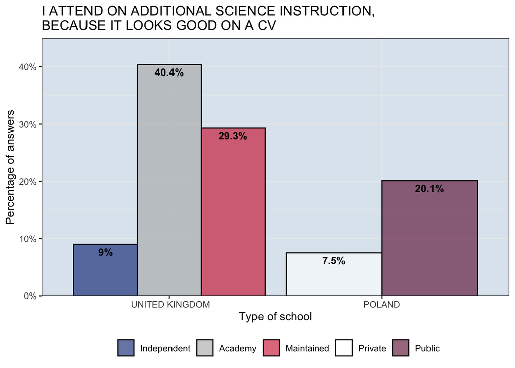

### 2

In the UK many students attend additional science instructions. In Independent schools, everyone claims they are/were attending an extracurricular class. In Poland, this factor is smaller.

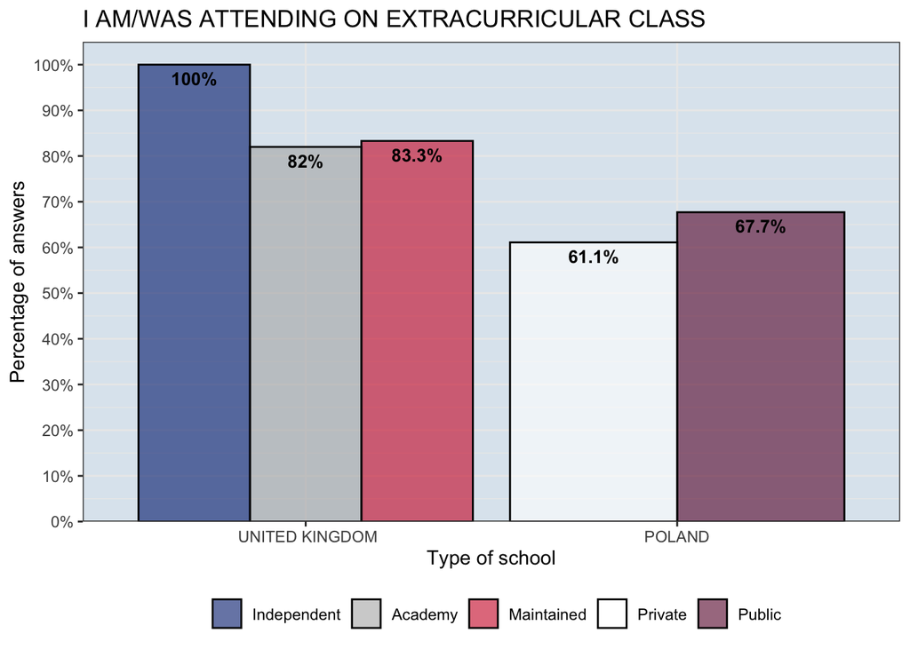

### 3

For Polish people, the study of Foreign language is more important than for UK people. However, Polish students comparatively to UK ones have only 0.5 of an hour per week of Foreign language in school. What’s more, the time that Polish people spend on learning doubles UK students’ time. It is one of the reasons, why the Polish school system is way lower than the UK’s in ranking-Poland have poorly designed school system and teachers require from pupils knowledged they do not teach them. That’s why children have to spend a lot of time in home studying.

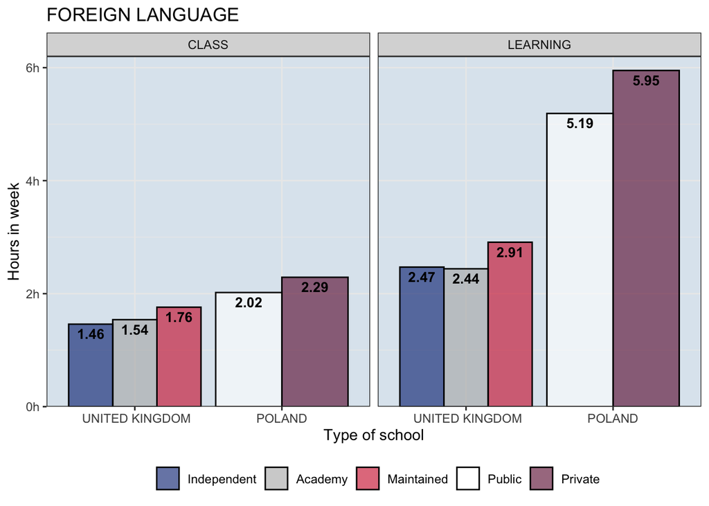

Paulinowe:  
1. Quality of school system isn’t only dependent from score on tests. UK is placed on 6th place thanks to it’s approach to education. It’s focused on pupils’ self-realization, comfort and relations student-teacher.  
2. UK categorize it’s schools by financing method:  
* Independent - Private and independent form goverment. Have it’s own sponsors and curriculum.  
* Academy - Have good reputation and are controled by goverment.  
* Maintained - Are controled by local authority. Closest to Polish public schools.